# Data Science II

Session 3: `sf` Objects and Basic Mapping

Bogdan G. Popescu

bgpopescu@tec.mx

Tec de Monterrey

## What You’ll Learn Today

1. What an **`sf` object actually is**, built from scratch
2. The three classes: **`sfg`**, **`sfc`**, and **`sf`**
3. Taking a layer apart — geometry, attributes, coordinates
4. Turning a **table of coordinates into a map** — the skill you will use most
5. Reading and writing the common **vector file formats**

By the end, you will map 6,460 real health establishments in Yucatán from a CSV.

## Where We Left Off

Last week: coordinates, CRS, the **seven geometry types**, and reading a shapefile with `st_read`.

We said an **`sf` object is a dataframe with a geometry column**, and left it there.

Today we open it up. Knowing what is inside is what lets you fix it when it breaks.

## Before We Start

Same folder shape as last week — code reads `../data/...`:

```
ciencia_datos_2/
├── data/
│   ├── gadm41_MEX_shp/
│   ├── denue/denue_salud_yucatan.csv
│   ├── mex_formats/
│   └── mexico_homicides.gpkg      <- download this one
└── session2/
    └── your_notes.qmd
```

Download the GeoPackage into `data/` now — nothing today opens it, but **Session 4** starts with it:

[mexico_homicides.gpkg](https://www.dropbox.com/scl/fi/icj5i9defldnre0utbbn1/mexico_homicides.gpkg?rlkey=454ow8ad7zfb6u5r3war5qnh8&dl=0)

## Where We Left Off

Everything today runs from this setup:

```r
library(sf)
library(ggplot2)
library(dplyr)
sf_use_s2(FALSE)
```

The complete, ordered code for this session is in **`session3_code.R`**.

# Part A: What an `sf` Object Is

## A Word on `sp`

The first R package for vector data was **`sp`** (2005), with its companions `rgdal` and `rgeos`.

They dominated spatial analysis in R for fifteen years. **`rgdal` and `rgeos` were retired from CRAN in 2023.** `sp` itself survives, but only in maintenance.

**Warning**

Do not start new work with them — but **recognise them**. Most Stack Overflow answers you find were written for `sp`, and anything calling `readOGR()` or `spTransform()` will not run today.

## The `sf` Package

`sf` is the standard package for working with vector data in R.

It relies on three external components: **GDAL** (reading formats), **GEOS** (geometry operations), and **PROJ** (projections).

It contains three classes, and they nest:

- **`sfg`** — a single geometry
- **`sfc`** — a geometry column: many `sfg` plus a CRS
- **`sf`** — a layer: an `sfc` inside a dataframe of attributes

Everything today is one of these three.

## The `sf` Class, Illustrated

A polygon layer with **three features** and **six non-spatial attributes** — built from the shapefile you already have:

```r
#Step1: Three states of the Yucatán peninsula
pen <- st_read("../data/gadm41_MEX_shp/gadm41_MEX_1.shp", quiet = TRUE) |>
  filter(NAME_1 %in% c("Yucatán", "Campeche", "Quintana Roo")) |>
  transmute(state    = NAME_1,
            country  = COUNTRY,
            type     = ENGTYPE_1,
            hasc     = HASC_1,
            area_km2 = round(as.numeric(st_area(st_transform(geometry, 6372))) / 1e6),
            parts    = lengths(geometry))
```

```r
#Step2: The attribute half -- an ordinary dataframe
st_drop_geometry(pen)
```

```
         state country  type  hasc area_km2 parts
1     Campeche  México State MX.CM    55307    75
2 Quintana Roo  México State MX.QR    43067    97
3      Yucatán  México State MX.YU    39102     6
```

## The `sf` Class, Illustrated

```r
#Step3: The spatial half -- one sfc, carrying the CRS
st_geometry(pen)
```

```
Geometry set for 3 features
Geometry type: MULTIPOLYGON
Dimension:     XY
Bounding box:  xmin: -92.467 ymin: 17.81514 xmax: -86.71074 ymax: 21.62427
Geodetic CRS:  WGS 84
```

Six columns of text and numbers, one column of geometry, **one object**. The `sfc` sits inside the dataframe exactly as the previous slide described.

## The `sf` Class, Mapped

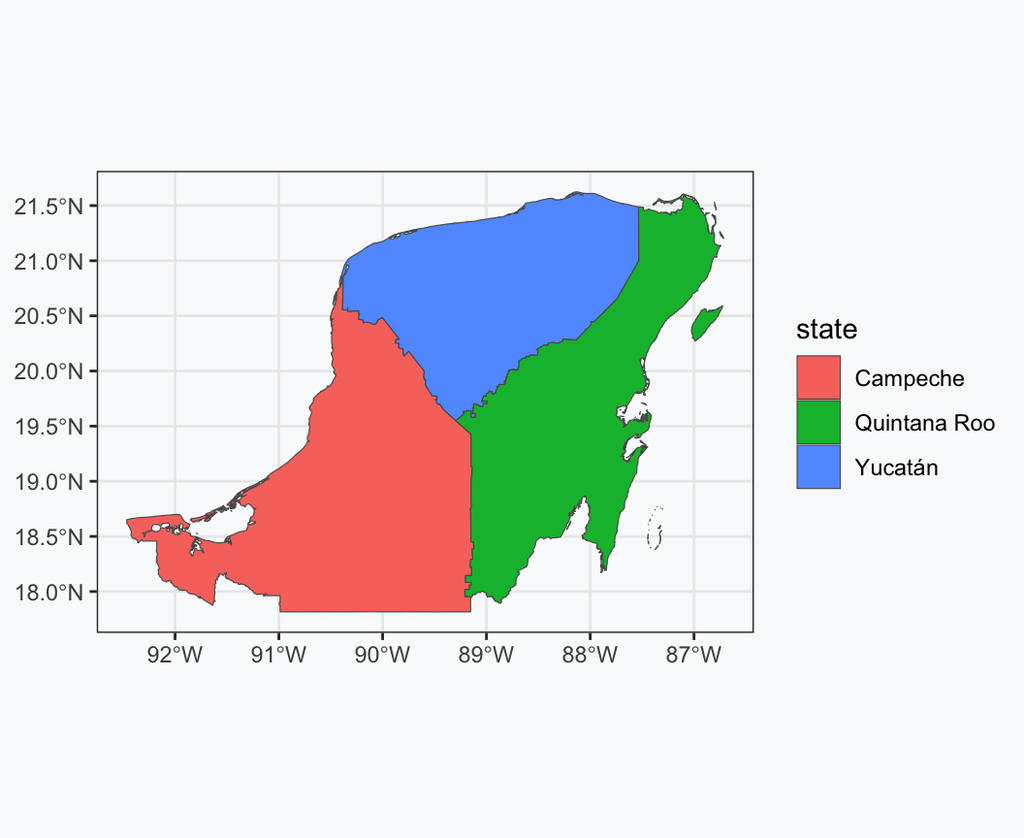

```r
#Step4: The same object, drawn
ggplot(pen) +
  geom_sf(aes(fill = state)) +
  theme_bw()
```

Attributes and geometry are two views of **one object**: `fill = state` reads a text column, `geom_sf` reads the geometry column, in a single call.

## What `parts` Was Telling You

Look again at that column: Campeche **75**, Quintana Roo **97**, Yucatán **6**.

Those are the pieces each `MULTIPOLYGON` is made of — the mainland, plus every offshore island. Quintana Roo carries Cozumel, Isla Mujeres and ninety-odd more.

**Note**

One **row** is not one **shape**. This is why the type is `MULTIPOLYGON` and not `POLYGON`, and why `lengths()` on a geometry column is a quick way to see what you actually have.

## Building a Point

Let us create one point — the centre of Mérida:

```r
library(sf)
library(ggplot2)
merida <- st_point(c(-89.6237, 20.9674))
```

Printing it gives the **WKT** (Well-Known Text) representation:

```r
print(merida)
```

[output not shown]

**Warning**

## What Class Is It?

```r
merida <- st_point(c(-89.6237, 20.9674))
class(merida)
```

```
[1] "XY"    "POINT" "sfg"
```

- **`XY`** — two-dimensional geometry
- **`POINT`** — the geometry type
- **`sfg`** — the general class: a simple feature geometry

Note what is **missing**: there is no CRS. A bare `sfg` is just numbers.

## Building a Polygon

```r
a <- st_polygon(list(cbind(c(0, 0, 7.5, 7.5, 0),
                           c(0, -1, -1, 0, 0))))
print(a)
```

[output not shown]

The first and last coordinate are **the same** — that is what closes the ring. Omit it and `sf` errors.

## Plotting the Polygon

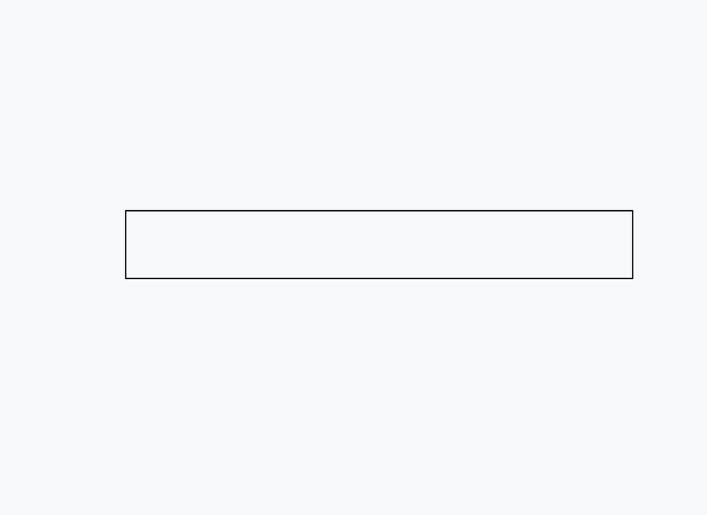

```r
a <- st_polygon(list(
  cbind(c(0, 0, 7.5, 7.5, 0),
        c(0, -1, -1, 0, 0))))

plot(a)
```

## The Same Polygon with `ggplot`

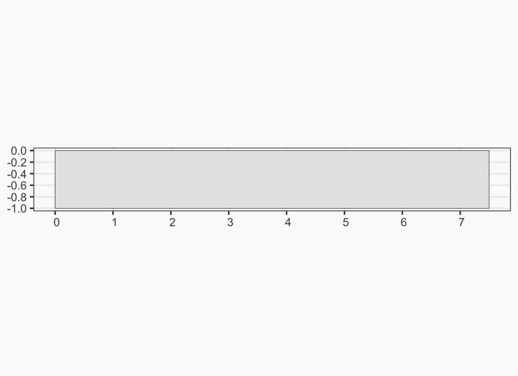

```r
ggplot() +
  geom_sf(data = a) +
  theme_bw()
```

`geom_sf` accepts a bare `sfg`. You rarely do this in practice — but it shows the geometry is the only thing `ggplot` needs.

## A More Complex Polygon

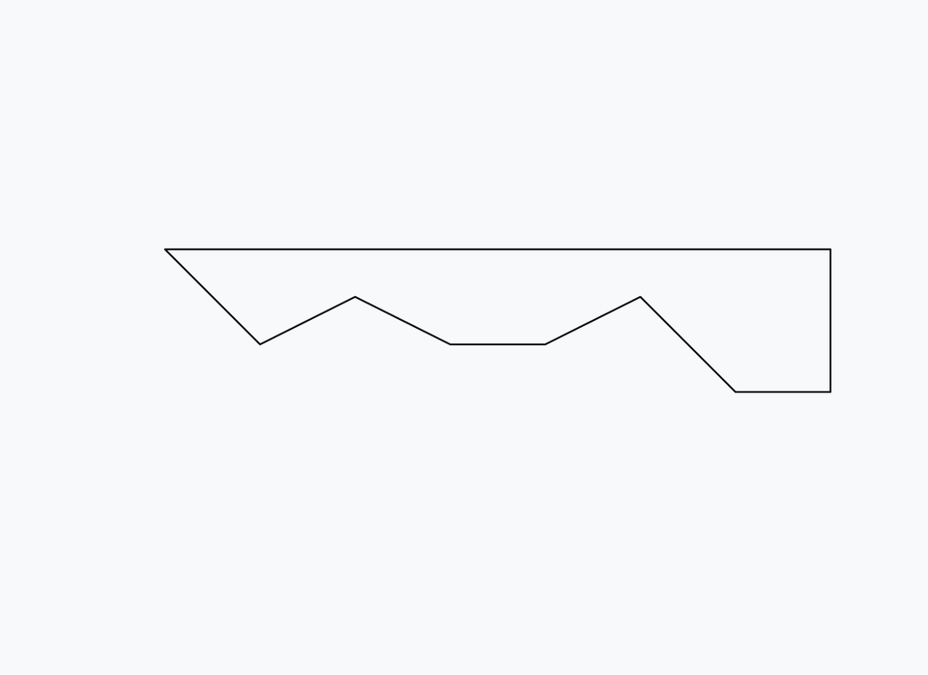

```r
b <- st_polygon(list(
  cbind(c(0,1,2,3,4,5,6,7,7,0),
        c(1,0,0.5,0,0,0.5,-0.5,-0.5,1,1))))

plot(b)
```

Same function, more vertices. A municipio boundary is this with a few thousand more.

## Combining Geometries

We combine geometries with `c()`:

```r
ab <- c(a, b)
class(ab)
```

```
[1] "XY"           "MULTIPOLYGON" "sfg"
```

The result is a single **`MULTIPOLYGON`** — one geometry composed of several shapes.

This is exactly what a state like Baja California Sur is: one feature, many islands.

## Plotting the Combination

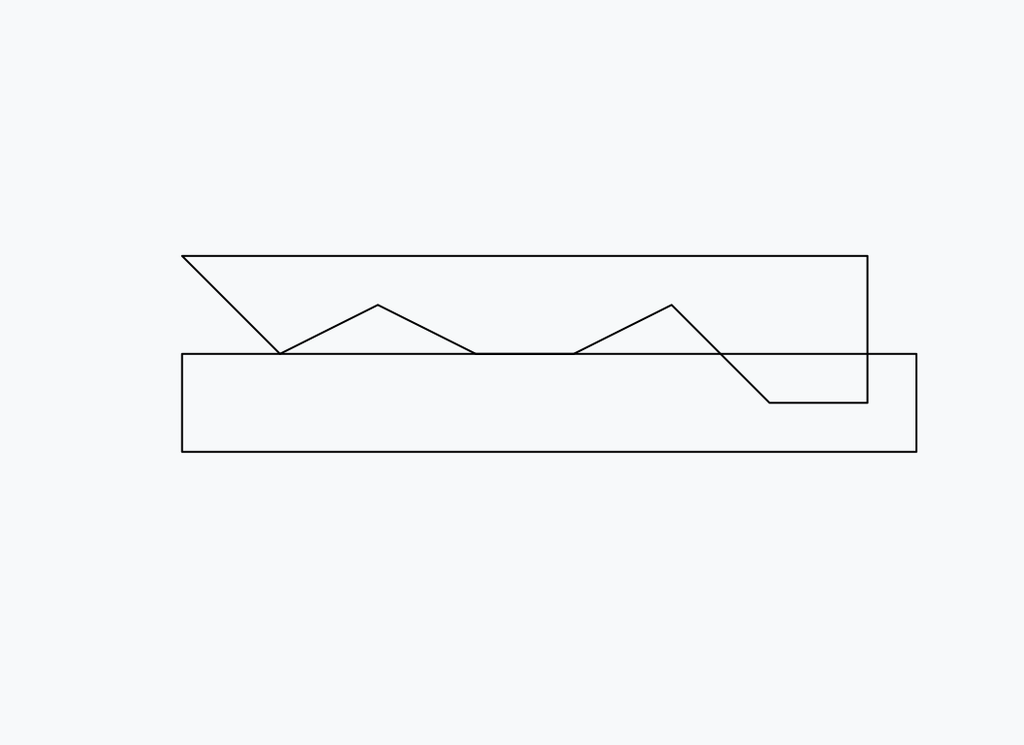

```r
ab <- c(a, b)
plot(ab)
```

## Intersecting Geometries

New geometries can be **calculated** from existing ones:

```r
i <- st_intersection(a, b)
class(i)
```

```
[1] "XY"                 "GEOMETRYCOLLECTION" "sfg"
```

Note the difference:

- `c(a, b)` gives a `MULTIPOLYGON` — everything in **either**
- `st_intersection(a, b)` gives what is in **both**

Intersection is the workhorse of Session 6. Here we just meet it.

## Combination and Intersection Compared

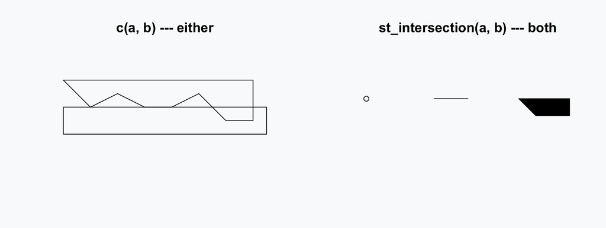

```r
#Step1: Two panels side by side
par(mfrow = c(1, 2))

#Step2: Everything in either shape, then only what is in both
plot(ab, main = "c(a, b) --- either")
plot(i,  main = "st_intersection(a, b) --- both")
```

# Part B: Geometry Columns and Layers

## The Geometry Column: `sfc`

A single geometry is rarely useful. We collect them into a **geometry column** with `st_sfc`.

Three points in Yucatán:

```r
#Step1: Three bare geometries -- longitude first, then latitude
merida     <- st_point(c(-89.6237, 20.9674))
valladolid <- st_point(c(-88.2020, 20.6896))
progreso   <- st_point(c(-89.6636, 21.2820))
```

An `sfc` — unlike an `sfg` — **carries a CRS**.

## Four Ways to Specify a CRS

- an **EPSG** code — `4326`
- a `crs` object, as returned by `st_crs()`
- a **PROJ4** string — `'+proj=longlat +datum=WGS84 +no_defs'`
- a **WKT** string

Use the EPSG code. It is shortest and least error-prone.

**Warning**

If you omit the `crs` argument, the CRS is set to `NA` — **undefined**. The object still works, still plots, and then fails the moment you combine it with anything else.

## The Same CRS, Written Differently

`st_crs()` accepts any of them, and hands back the **same** object.

```r
#Step1: The same code, written as a string
code  <- st_crs("EPSG:4326")

#Step2: A PROJ4 string -- the old way, still common in the wild
proj4 <- st_crs("+proj=longlat +datum=WGS84 +no_defs")
```

Different spellings, one CRS. The remaining way — passing a `crs` object you already have — is just reusing one of these.

## Where You Actually Use Them

Anywhere `sf` asks for a CRS, **any** of those spellings is accepted.

```r
#Step1: Set it when you build the object -- the integer
pts <- st_sfc(merida, valladolid, progreso, crs = 4326)

#Step2: Repair one that arrived without a crs -- the object from before
bare <- st_sfc(merida, valladolid, progreso)
st_crs(bare) <- code

#Step3: Change it -- degrees to metres
metres <- st_transform(pts, 6372)

#Step4: What each one ended up with
c(st_crs(pts)$input, st_crs(bare)$input, st_crs(metres)$input)
```

```
[1] "EPSG:4326" "EPSG:4326" "EPSG:6372"
```

## Setting Is Not Transforming

The two operations look similar and do **opposite** things.

```r
#Step1: The units tell you which CRS you are in
c(st_crs(pts)$units_gdal, st_crs(metres)$units_gdal)
```

```
[1] "degree" "metre"
```

```r
#Step2: st_transform MOVED the coordinates
st_coordinates(pts)[1, ]
```

```
       X        Y
-89.6237  20.9674
```

```r
st_coordinates(metres)[1, ]
```

```
      X       Y
3779728 1050585
```

**Warning**

`st_crs(x) <- 4326` only writes a **label**: it says “these numbers were always in WGS84” and moves nothing. `st_transform(x, 6372)` recomputes every coordinate. Use the first to *repair* a missing CRS, the second to *change* one — never the first to convert.

## What Is Inside a `crs` Object

```r
#Step1: What you passed in
st_crs(4326)$input
```

```
[1] "EPSG:4326"
```

```r
#Step2: The integer code on its own
st_crs(4326)$epsg
```

```
[1] 4326
```

```r
#Step3: The PROJ4 representation
st_crs(4326)$proj4string
```

```
[1] "+proj=longlat +datum=WGS84 +no_defs"
```

This is why you type `4326` and not a WKT string. Same CRS, four characters.

## Building an `sfc`

```r
combined <- st_sfc(merida, valladolid, progreso, crs = 4326)
combined
```

```
Geometry set for 3 features
Geometry type: POINT
Dimension:     XY
Bounding box:  xmin: -89.6636 ymin: 20.6896 xmax: -88.202 ymax: 21.282
Geodetic CRS:  WGS 84
```

Notice what printing gives you now: geometry type, dimension, **bounding box**, and **CRS**. None of that existed on the bare `sfg`.

## Plotting the `sfc`

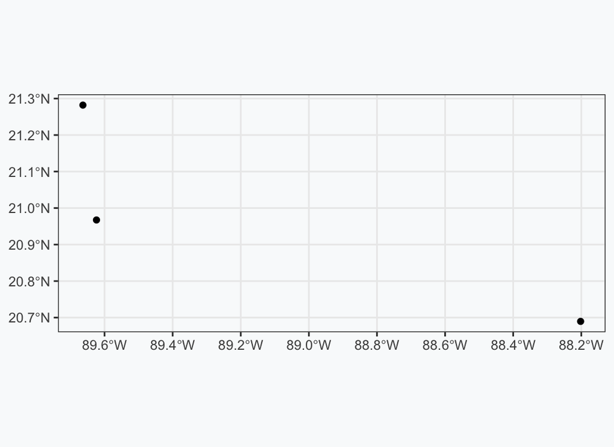

```r
ggplot() +
  geom_sf(data = combined) +
  theme_bw()
```

Three points, no attributes. Useful, but we cannot yet say *which* is which.

## From `sfc` to `sf`: Adding Attributes

```r
#Step1: An ordinary attribute table, one row per geometry
names_df <- data.frame(
  city = c("Mérida", "Valladolid", "Progreso"),
  population = c(995129, 85460, 63400))

#Step2: Weld the attributes to the geometry column
layer <- st_sf(names_df, combined)
layer
```

```
Simple feature collection with 3 features and 2 fields
Geometry type: POINT
Dimension:     XY
Bounding box:  xmin: -89.6636 ymin: 20.6896 xmax: -88.202 ymax: 21.282
Geodetic CRS:  WGS 84
        city population                 combined
1     Mérida     995129 POINT (-89.6237 20.9674)
2 Valladolid      85460  POINT (-88.202 20.6896)
3   Progreso      63400  POINT (-89.6636 21.282)
```

`st_sf()` welds an attribute table to a geometry column. **That is all an `sf` object is.**

## Mapping with `plot()`

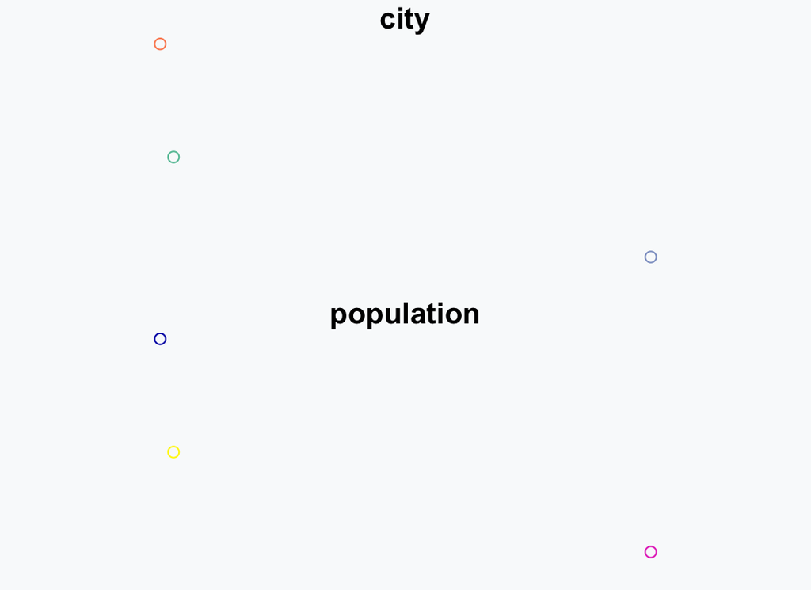

```r
plot(layer)
```

Base `plot()` draws **one panel per attribute** — here, city and population.

## Mapping with `ggplot()`

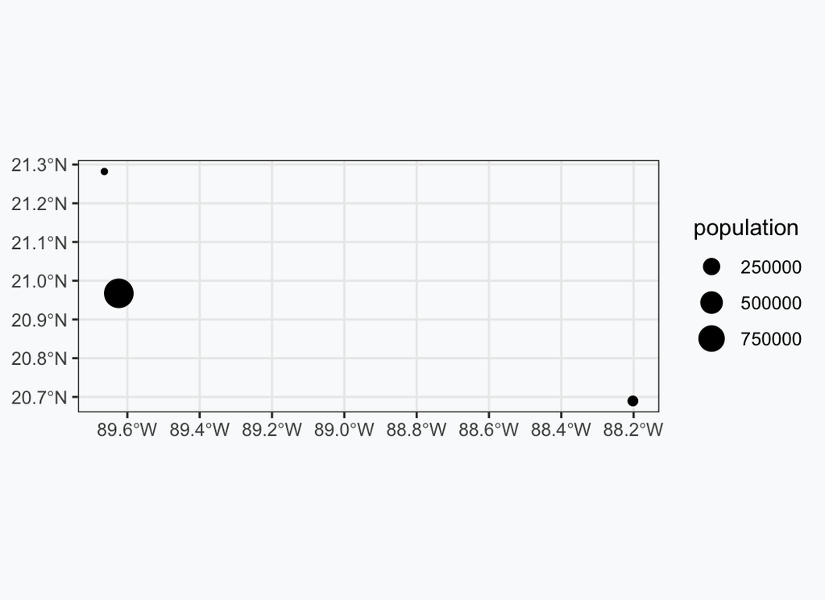

```r
ggplot() +
  geom_sf(data = layer, aes(size = population)) +
  theme_bw()
```

## `plot()` or `ggplot()`?

**`plot()`**

- Instant, zero typing
- Shows every attribute at once
- Good for **checking** data

**`ggplot()`**

- Full control of colour, size, legend
- Layers stack
- Good for **producing** maps

**Tip**

Use `plot()` while you work, `ggplot()` for anything anyone else will see. Getting into the habit of `plot()`-ing a layer the moment you read it catches most data problems in two seconds.

# Part C: Taking a Layer Apart

## Extracting Layer Components

Sometimes you need to go the other way and pull out:

- the **geometry**
- the **attribute table**
- the **coordinates**

## The Geometry

```r
st_geometry(layer)
```

```
Geometry set for 3 features
Geometry type: POINT
Dimension:     XY
Bounding box:  xmin: -89.6636 ymin: 20.6896 xmax: -88.202 ymax: 21.282
Geodetic CRS:  WGS 84
```

This gives you back the `sfc` — geometry and CRS, no attributes.

## The Attribute Table

```r
st_drop_geometry(layer)
```

```
        city population
1     Mérida     995129
2 Valladolid      85460
3   Progreso      63400
```

A plain dataframe. Use this whenever you want to inspect, summarise, or export attributes without dragging thousands of coordinates along.

## The Coordinates

```r
st_coordinates(layer)
```

```
            X       Y
[1,] -89.6237 20.9674
[2,] -88.2020 20.6896
[3,] -89.6636 21.2820
```

A **matrix**. Turn it into a dataframe when you need it as data:

```r
head(data.frame(st_coordinates(layer)), 2)
```

```
         X       Y
1 -89.6237 20.9674
2 -88.2020 20.6896
```

# Part D: From a Table to a Map

## The Skill You Will Use Most

Most data does not arrive as a shapefile. It arrives as a **spreadsheet with a latitude column and a longitude column**.

Turning that into a map is one function: **`st_as_sf()`**.

## The Data: DENUE

**DENUE** — *Directorio Estadístico Nacional de Unidades Económicas* — is INEGI’s register of every economic establishment in Mexico, **with coordinates**.

Today’s extract: every **health establishment in Yucatán**.

- 6,460 establishments
- 106 municipios
- clinics, dental practices, laboratories, care homes

The source: https://www.inegi.org.mx/app/mapa/denue/

Today’s extract, ready to use: [denue_salud_yucatan.csv](https://www.dropbox.com/scl/fi/dwphvtpr73vb7w6tqfs8m/denue_salud_yucatan.csv?rlkey=ocko0utdvshwgmchffyl4zoez&dl=0)

## Reading the Table

```r
#Step1: Read the DENUE extract -- an ordinary CSV, no geometry yet
df <- read.csv("../data/denue/denue_salud_yucatan.csv")
dim(df)
```

```
[1] 6460   15
```

```r
names(df)
```

```
 [1] "id"         "nom_estab"  "codigo_act" "nombre_act" "per_ocu"
 [6] "cve_ent"    "entidad"    "cve_mun"    "municipio"  "localidad"
[11] "telefono"   "www"        "tipoUniEco" "latitud"    "longitud"
```

The two columns that matter: **`longitud`** and **`latitud`**.

## `st_as_sf()`: Table to Layer

```r
#Step1: Turn the two coordinate columns into a geometry column
#       x first (longitud), then y (latitud); always give a crs
pts <- st_as_sf(df, coords = c("longitud", "latitud"), crs = 4326)
class(pts)
```

```
[1] "sf"         "data.frame"
```

```r
dim(df)
```

```
[1] 6460   15
```

```r
dim(pts)
```

```
[1] 6460   14
```

Fifteen columns became fourteen: `longitud` and `latitud` were **consumed** and replaced by one `geometry` column.

**Warning**

`coords = c("longitud", "latitud")` — **x first, then y**. And always pass `crs = 4326`; without it the layer is undefined.

## Mapping the Points

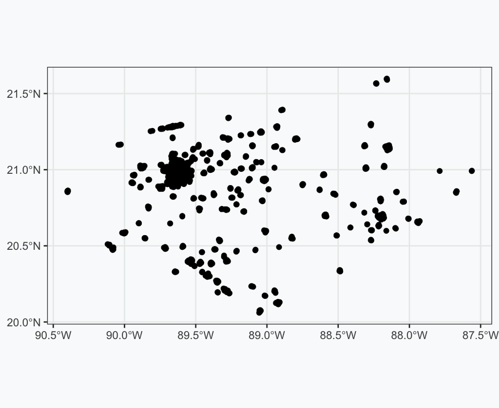

```r
ggplot() +
  geom_sf(data = pts) +
  theme_bw()
```

Six thousand dots. You can see Mérida, and you can guess at the coast — but only if you already know Yucatán.

## Points Need Context

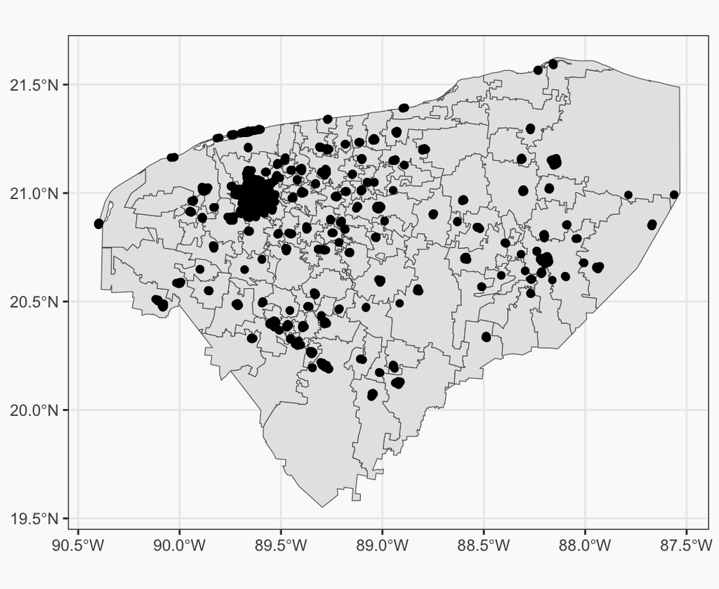

```r
#Step1: Read municipio polygons (GADM level 2)
mex <- st_read(
  "../data/gadm41_MEX_shp/gadm41_MEX_2.shp",
  quiet = TRUE)

#Step2: Keep only Yucatán
yuc <- mex[mex$NAME_1 == "Yucatán", ]

#Step3: Polygons first, points on top
ggplot() +
  geom_sf(data = yuc) +
  geom_sf(data = pts) +
  theme_bw()
```

## `sf` Properties: Rows and Columns

```r
nrow(pts)
```

```
[1] 6460
```

```r
ncol(pts)
```

```
[1] 14
```

```r
dim(pts)
```

```
[1] 6460   14
```

All the base R you know still applies. The geometry column counts as one column.

## `sf` Properties: Bounding Box

```r
st_bbox(pts)
```

```
     xmin      ymin      xmax      ymax
-90.40105  20.06068 -87.56142  21.59810
```

The extreme coordinates: westernmost, southernmost, easternmost, northernmost.

**Tip**

`st_bbox` is your **first sanity check**. If the numbers are not roughly where Yucatán should be (about -90 to -87, 20 to 22), something is wrong — usually swapped coordinates.

## `sf` Properties: CRS

```r
st_crs(pts)$input
```

```
[1] "EPSG:4326"
```

```r
st_crs(pts)$units_gdal
```

```
[1] "degree"
```

Degrees — because we set 4326. To measure anything in metres, `st_transform(pts, 6372)` first.

## Subsetting by Attributes

Only the establishments that list a telephone number:

```r
#Step1: Keep only rows that list a telephone number
with_phone <- subset(pts, telefono != "" & !is.na(telefono))

#Step2: How many did we lose?
nrow(pts)
```

```
[1] 6460
```

```r
nrow(with_phone)
```

```
[1] 3584
```

Ordinary `subset()`. The geometry follows the rows automatically — you never subset the geometry yourself.

## Comparing the Subsets

```r
#Step1: patchwork lets us place two ggplots side by side with |
library(patchwork)
```

## Comparing the Subsets

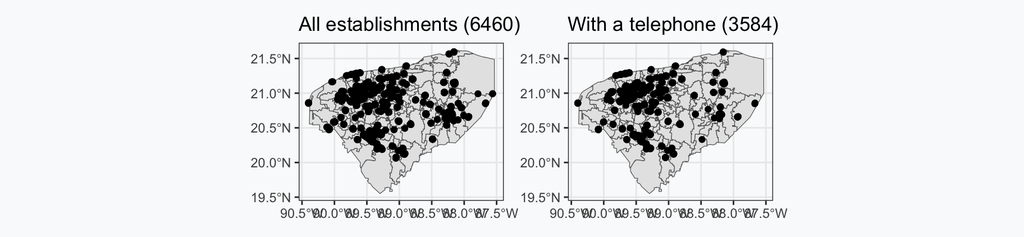

```r
f1 <- ggplot() +
  geom_sf(data = yuc) +
  geom_sf(data = pts) +
  ggtitle(paste0("All establishments (", nrow(pts), ")")) +
  theme_bw()
f2 <- ggplot() +
  geom_sf(data = yuc) +
  geom_sf(data = with_phone) +
  ggtitle(paste0("With a telephone (", nrow(with_phone), ")")) +
  theme_bw()
f1 | f2
```

Just over half. And the ones that drop out are **not randomly distributed** — a reminder that missing data is itself spatial.

## Subsetting Columns

Selecting columns works as it does on any dataframe — with one difference:

```r
small <- pts[, c("nom_estab", "municipio")]
names(small)
```

```
[1] "nom_estab" "municipio" "geometry"
```

You asked for two columns and got three. **The geometry column is sticky** — it comes along unless you explicitly drop it.

## Dropping the Geometry

```r
plain <- st_drop_geometry(small)
names(plain)
```

```
[1] "nom_estab" "municipio"
```

```r
class(plain)
```

```
[1] "data.frame"
```

Now it is an ordinary dataframe. Do this before `write.csv`, or before any operation that does not need the geometry — it is dramatically faster.

# Part E: Reading and Writing Files

## Reading a Shapefile

Download first — the whole **folder**, not a single file: [gadm41_MEX_shp](https://www.dropbox.com/scl/fo/5jkxbgp29r54zy8ero09h/AL3AFvnq14D4piZ8pQKZRjg?rlkey=6vgggjk5gl4kag50vtyoczn2x&dl=0)

```r
states_shp <- st_read("../data/gadm41_MEX_shp/gadm41_MEX_1.shp", quiet = TRUE)
nrow(states_shp)
```

```
[1] 32
```

## Reading a GeoJSON

Download first: [mex_states.geojson](https://www.dropbox.com/scl/fi/wnqcp4lab5uorzaevuqjb/mex_states.geojson?rlkey=k0z3jbsl7gri44hmay1l2qzxt&dl=0)

```r
states_json <- st_read("../data/mex_formats/mex_states.geojson", quiet = TRUE)
nrow(states_json)
```

```
[1] 32
```

One file, plain text. Open it in a text editor and you can read the coordinates.

## Reading a GeoPackage

Download first: [mex_states.gpkg](https://www.dropbox.com/scl/fi/h7o9ykp2xgp8v5bszl71t/mex_states.gpkg?rlkey=s3kdfdox8gyc5u9x1ogdwswsv&dl=0)

```r
states_gpkg <- st_read("../data/mex_formats/mex_states.gpkg", quiet = TRUE)
nrow(states_gpkg)
```

```
[1] 32
```

One file, binary, and it can hold **many layers** at once. `st_layers()` tells you what is inside.

## Which Format Should You Use?

|  | Use it when |
| --- | --- |
| **Shapefile** | someone insists — it is the old standard |
| **GeoJSON** | small data, web maps, version control |
| **GeoPackage** | **your default** — one file, no size limit, multiple layers |

**Warning**

Shapefile limitations that will bite you: column names truncated to **10 characters**, a **2 GB** size cap, and no proper support for accented characters. `Nombre_del_Municipio` becomes `Nombre_del`.

## Writing Files

```r
st_write(with_phone, "salud_yucatan.gpkg", delete_dsn = TRUE)
st_write(with_phone, "salud_yucatan.geojson", delete_dsn = TRUE)
```

`st_write` picks the format from the **file extension**. `delete_dsn = TRUE` overwrites; without it, a second run errors.

## What Have We Learned?

- An `sf` object is three nested things: **`sfg`** → **`sfc`** → **`sf`**
- A bare geometry has **no CRS**; an `sfc` does
- `st_sf()` welds attributes to geometry — that is the whole trick
- `st_geometry`, `st_drop_geometry`, `st_coordinates` take a layer apart
- **`st_as_sf(df, coords = c("lon", "lat"), crs = 4326)`** turns any table into a map
- The geometry column is **sticky** — it survives subsetting until you drop it
- **GeoPackage** should be your default format, not shapefile

**Next session:** choropleths — joining data to boundaries, classification, colour, and interactive maps with `leaflet`.